# Relatório

Trabalhos iniciais com a Base de Dados TJSP

José Luiz Cavalcanti

30/09/2024

# Introdução

Neste projeto inicial iremos verificar as bases de dados que temos para trabalhar para responder as seguintes perguntas do nosso TCC, com relação as alterações da lei de Improbidade Adiminstrativa:

## Decisões em Segunda Instância momento de alteração:

Inicialmente vamos buscar e baixar os pacotes que precisamos, bem como carregar nossa base de dados.

```r
library(dplyr)
library(rdrobust)
library(ggplot2)
library(readxl)
library(readr)
library(stringr)
library(rdd)
library(rddtools)
BaseTJSP <- read_xlsx("C:/Users/José Luiz/Documents/BMAC/TCC/Base de dados decisão TJSP.xlsx")
BasePrimeira <- read_xlsx("C:/Users/José Luiz/Documents/BMAC/TCC/BaseDados 1ª Instância Bruta.xlsx")
```

```r
novo_df <- BaseTJSP %>%
  filter(`Situação do Provimento` %in% c('Provimento', 'Não-Provimento',
                                         'Provimento em Parte'))

novo_df <- novo_df %>%
  mutate(`Situação do Provimento` = ifelse(`Situação do Provimento` == "Provimento em Parte", "Provimento", `Situação do Provimento`))

novo_df <- novo_df %>%
  mutate(`Principal Parte Ativa` = case_when(
    str_detect(`Principal Parte Ativa`, "Ministério") ~ "Ente 1",
    str_detect(`Principal Parte Ativa`, "Prefeitura") | str_detect(`Principal Parte Ativa`, "Município") | str_detect(`Principal Parte Ativa`, "Estado") ~ "Ente 2",
    TRUE ~ "Particular"
  ))
novo_df <- novo_df %>%
  mutate(`Principal Parte Passiva` = case_when(
    str_detect(`Principal Parte Passiva`, "Ministério") ~ "Ente 1",
    str_detect(`Principal Parte Passiva`, "Prefeitura") | str_detect(`Principal Parte Passiva`, "Município") | str_detect(`Principal Parte Passiva`, "Estado") ~ "Ente 2",
    TRUE ~ "Particular"
  ))

novo_df <- novo_df %>%
  filter(`Assunto Principal` %in% c('10011-Improbidade Administrativa'))

#novo_df <- novo_df %>%
  #filter(novo_df$`Ação Classe do PG` %in% c('64 - Ação Civil de Improbidade Administrativa'))

library(lubridate)
novo_df$`Data da Movimentação` <- as.Date(novo_df$`Data da Movimentação`)

novo_df <- novo_df %>%
  filter(novo_df$`Data da Movimentação` >= '2016-01-01')

novo_df$Ano <- format(novo_df$`Data da Movimentação`, "%Y")
novo_df$Mes <- format(novo_df$`Data da Movimentação`, "%m")
novo_df$Semestre <- as.numeric(cut(as.numeric(format(novo_df$`Data da Movimentação`, "%m")), breaks = c(0, 6, 12), labels = FALSE))
novo_df$Bimestre <- as.numeric(cut(as.numeric(format(novo_df$`Data da Movimentação`, "%m")), breaks = c(0, 2, 4, 6, 8, 10, 12), labels = FALSE))
```

Inicialmente os tratamentos efetuados foram: Definir que qualquer tipo de provimento, quer seja parcial ou integral encontra-se com o status de Provimento, e a outra hipótese é de não provimento.

Segundo, foram feitos ajustes nas designações das partes envolvidas para proteger as informações além de restringir em três tipos de envolvidos: Ente 1 - recursos do MP, Ente 2 - recursos de entes públicos (Prefeituras e Estado de São Paulo), 3 - Particulares.

Terceiro, foram somente considerados os casos de improbidade adminsitrativa stricto sensu, ou seja uma das 3 hipóteses abarcadas pela lei de improbidade administrativa, referente ao art. 10 da Lei. (As condutas estão nos artigos 10, 11 e 12 da Lei 8429/92).

Por fim filtramos a base de dados para os processos referentes a 2016 até meados de 2024, e fizemos a definição da coluna mês, ano, bimestre e semestre para utilizar em nossos agrupamentos iniciais. Depois foi verificada o percentual anual de acordo com o resultado dos recursos em Segunda Instância.

- Total sem discriminação das partes

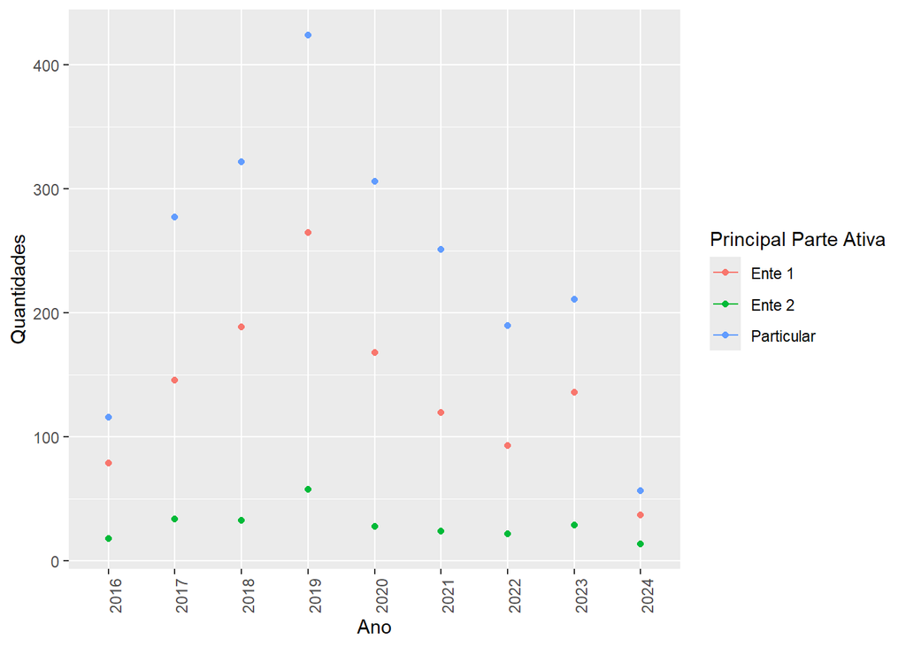

```r
dados_agrupados1 <- novo_df %>%
  group_by(Ano, `Principal Parte Ativa`) %>%
  summarise(Contagem = n())

total_por_ano <- dados_agrupados1 %>%
  group_by(Ano) %>%
  summarise(Total = sum(Contagem))

dados_agrupados1 <- merge(dados_agrupados1, total_por_ano, by = c("Ano"))

dados_agrupados1$Percentual <- (dados_agrupados1$Contagem / dados_agrupados1$Total) * 100

ggplot(dados_agrupados1, aes(x = interaction(Ano, sep = "-"), y = Contagem, color = `Principal Parte Ativa`)) +
  geom_line() +
  geom_point() +
  labs(x = "Ano", y = "Quantidades") +
  theme(axis.text.x = element_text(angle = 90, hjust = 1))
```

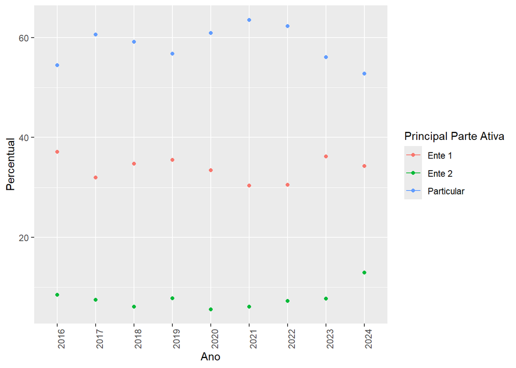

```r
ggplot(dados_agrupados1, aes(x = interaction(Ano, sep = "-"), y = Percentual, color = `Principal Parte Ativa`)) +
  geom_line() +
  geom_point() +
  labs(x = "Ano", y = "Percentual") +
  theme(axis.text.x = element_text(angle = 90, hjust = 1))
```

- Neste segundo grupo analisamos os processos cujo recurso tenha sido do MP e seu comportamento ao longo do ano:

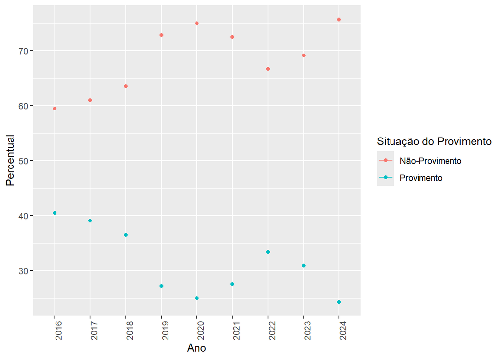

```r
dados_agrupados2 <- subset(novo_df, novo_df$`Principal Parte Ativa` == 'Ente 1') %>%
  group_by(Ano, `Situação do Provimento`) %>%
  summarise(Contagem = n())

total_por_ano <- dados_agrupados2 %>%
  group_by(Ano) %>%
  summarise(Total = sum(Contagem))

dados_agrupados2 <- merge(dados_agrupados2, total_por_ano, by = c("Ano"))

dados_agrupados2$Percentual <- (dados_agrupados2$Contagem / dados_agrupados2$Total) * 100


ggplot(dados_agrupados2, aes(x = interaction(Ano, sep = "-"), y = Percentual, color = `Situação do Provimento`)) +
  geom_line() +
  geom_point() +
  labs(x = "Ano", y = "Percentual") +
  theme(axis.text.x = element_text(angle = 90, hjust = 1))
```

- Agora considerando os demais entes públicos que podem ser autores da ação, como recorrentes e no percentual dos resultados.

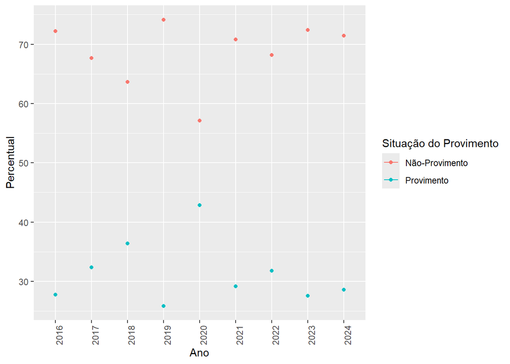

```r
dados_agrupados3 <- subset(novo_df, novo_df$`Principal Parte Ativa` == 'Ente 2') %>%
  group_by(Ano, `Situação do Provimento`) %>%
  summarise(Contagem = n())

total_por_ano <- dados_agrupados3 %>%
  group_by(Ano) %>%
  summarise(Total = sum(Contagem))

dados_agrupados3 <- merge(dados_agrupados3, total_por_ano, by = c("Ano"))

dados_agrupados3$Percentual <- (dados_agrupados3$Contagem / dados_agrupados3$Total) * 100


ggplot(dados_agrupados3, aes(x = interaction(Ano, sep = "-"), y = Percentual, color = `Situação do Provimento`)) +
  geom_line() +
  geom_point() +
  labs(x = "Ano", y = "Percentual") +
  theme(axis.text.x = element_text(angle = 90, hjust = 1))
```

- Por fim os casos em que os particulares, via de regra a parte passiva das ações de Improbidade Administrativa, quando os mesmos recorreram, e os percentuais de sucesso nos seus recursos:

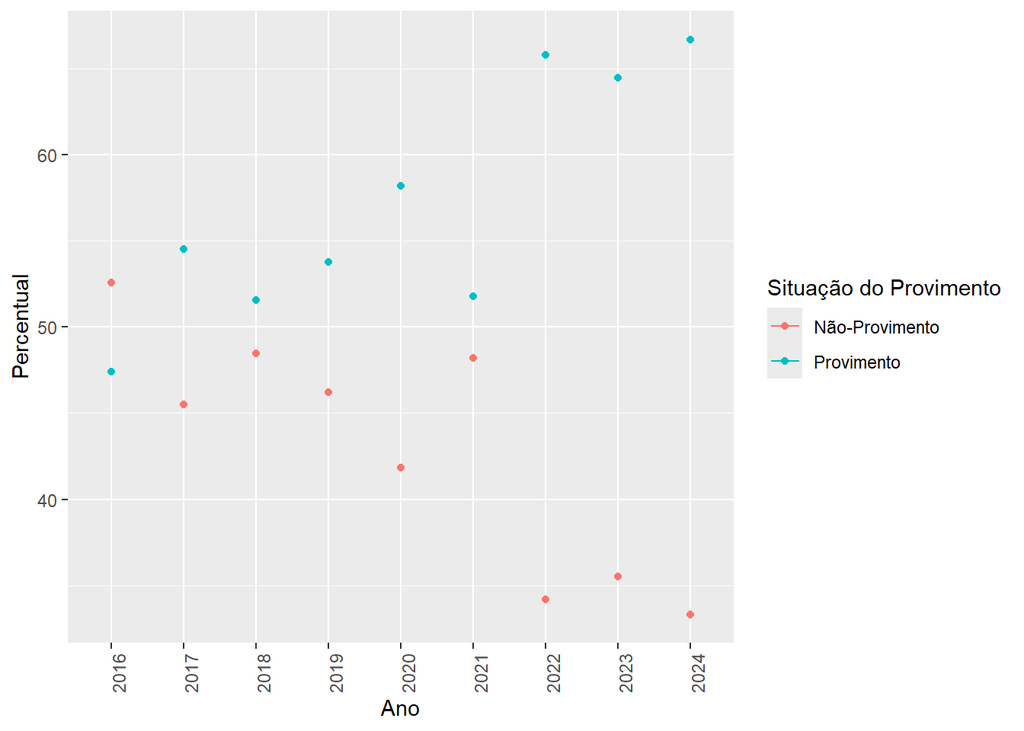

```r
dados_agrupados4 <- subset(novo_df, novo_df$`Principal Parte Ativa` == 'Particular') %>%
  group_by(Ano, `Situação do Provimento`) %>%
  summarise(Contagem = n())

total_por_ano <- dados_agrupados4 %>%
  group_by(Ano) %>%
  summarise(Total = sum(Contagem))

dados_agrupados4 <- merge(dados_agrupados4, total_por_ano, by = c("Ano"))

dados_agrupados4$Percentual <- (dados_agrupados4$Contagem / dados_agrupados4$Total) * 100


ggplot(dados_agrupados4, aes(x = interaction(Ano, sep = "-"), y = Percentual, color = `Situação do Provimento`)) +
  geom_line() +
  geom_point() +
  labs(x = "Ano", y = "Percentual") +
  theme(axis.text.x = element_text(angle = 90, hjust = 1))
```

Segue agora mais dois agrupamentos, por bimestre e por semestre: - Bimestre para MP

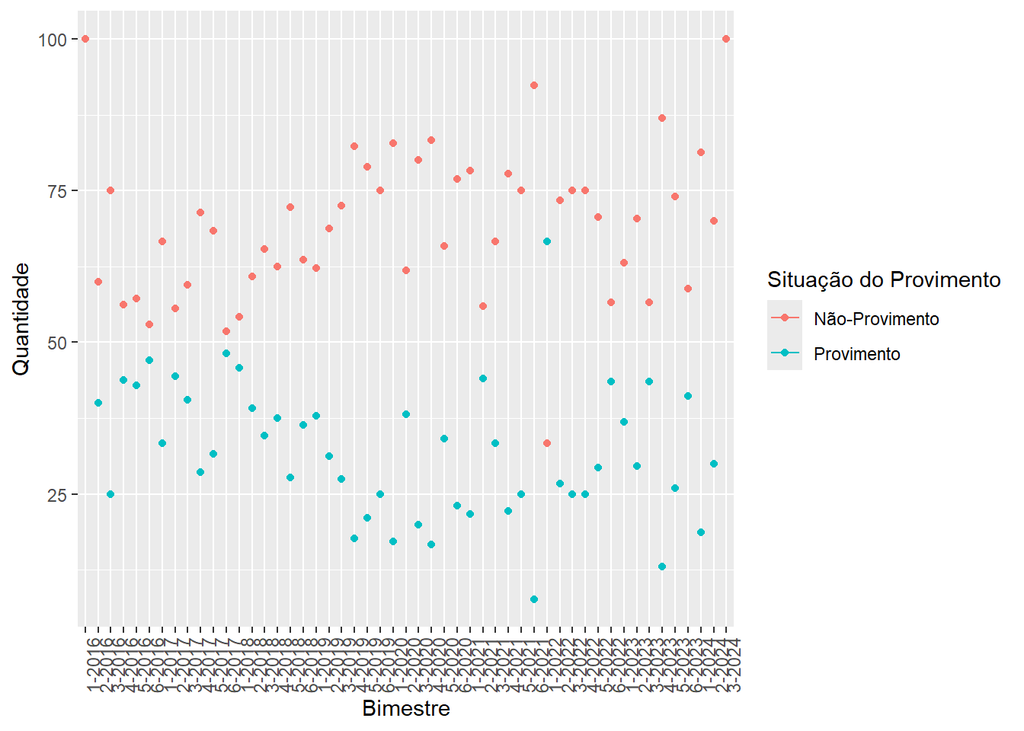

```r
#MP por Bimestre
dados_agrupados21 <- subset(novo_df, novo_df$`Principal Parte Ativa` == 'Ente 1') %>%
  group_by(Ano, Bimestre, `Situação do Provimento`) %>%
  summarise(Contagem = n())

total_por_bimestre <- dados_agrupados21 %>%
  group_by(Ano, Bimestre) %>%
  summarise(Total = sum(Contagem))

dados_agrupados21 <- merge(dados_agrupados21, total_por_bimestre, by = c("Ano", "Bimestre"))

dados_agrupados21$Percentual <- (dados_agrupados21$Contagem / dados_agrupados21$Total) * 100


ggplot(dados_agrupados21, aes(x = interaction(Bimestre, Ano, sep = "-"), y = Percentual, color = `Situação do Provimento`)) +
  geom_line() +
  geom_point() +
  labs(x = "Bimestre", y = "Quantidade") +
  theme(axis.text.x = element_text(angle = 90, hjust = 1))
```

- Bimestre para Particular

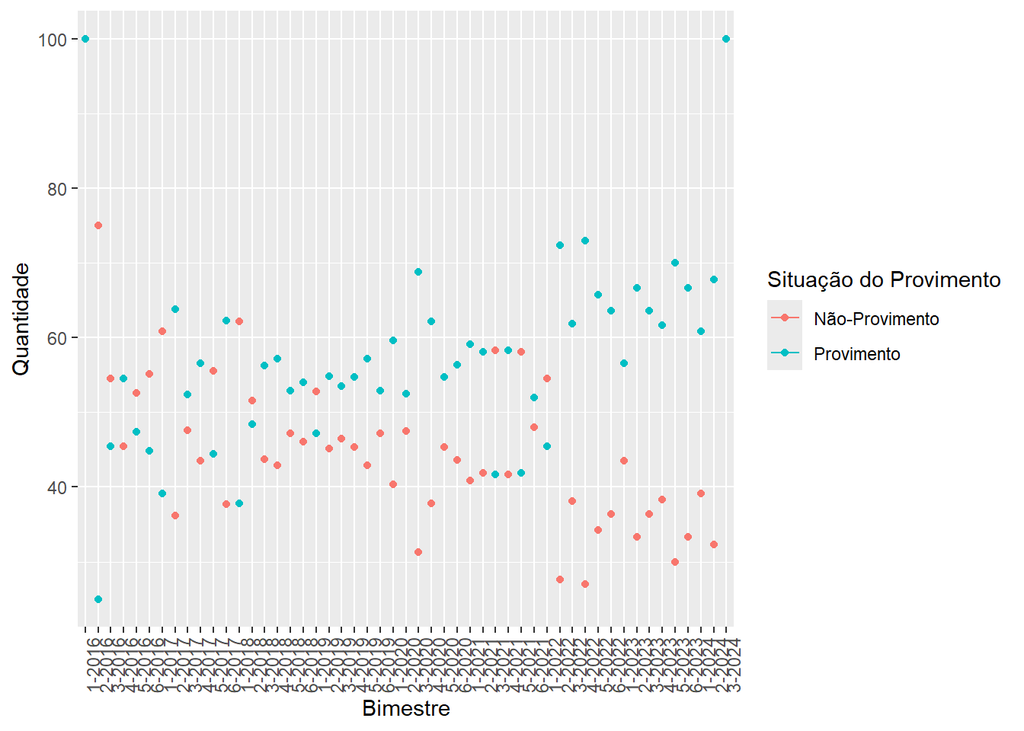

```r
#Bimestre Particular
dados_agrupados41 <- subset(novo_df, novo_df$`Principal Parte Ativa` == 'Particular') %>%
  group_by(Ano, Bimestre, `Situação do Provimento`) %>%
  summarise(Contagem = n())

total_por_bimestre <- dados_agrupados41 %>%
  group_by(Ano, Bimestre) %>%
  summarise(Total = sum(Contagem))

dados_agrupados41 <- merge(dados_agrupados41, total_por_bimestre, by = c("Ano", "Bimestre"))

dados_agrupados41$Percentual <- (dados_agrupados41$Contagem / dados_agrupados41$Total) * 100


ggplot(dados_agrupados41, aes(x = interaction(Bimestre, Ano, sep = "-"), y = Percentual, color = `Situação do Provimento`)) +
  geom_line() +
  geom_point() +
  labs(x = "Bimestre", y = "Quantidade") +
  theme(axis.text.x = element_text(angle = 90, hjust = 1))
```

Agora para semestral:

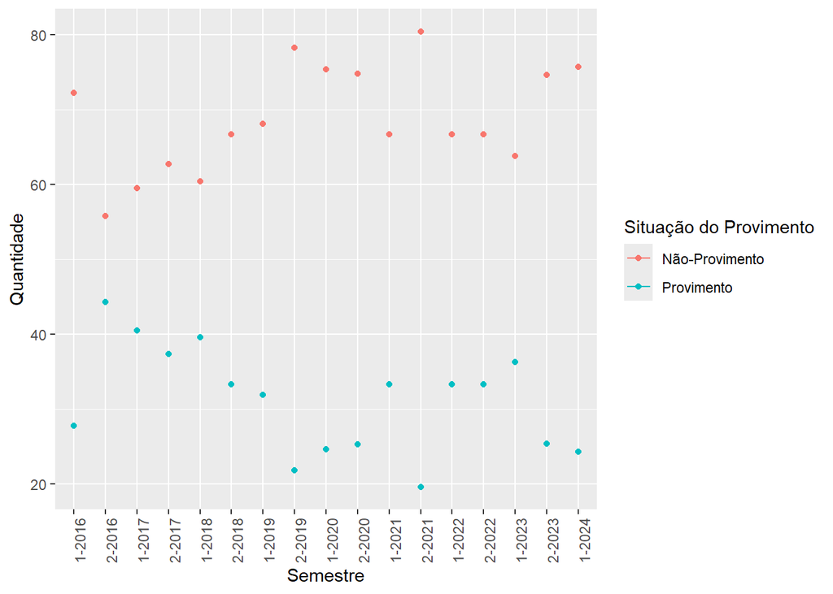

```r
#MP por semestre
dados_agrupados22 <- subset(novo_df, novo_df$`Principal Parte Ativa` == 'Ente 1') %>%
  group_by(Ano, Semestre, `Situação do Provimento`) %>%
  summarise(Contagem = n())

total_por_semestre <- dados_agrupados22 %>%
  group_by(Ano, Semestre) %>%
  summarise(Total = sum(Contagem))

dados_agrupados22 <- merge(dados_agrupados22, total_por_semestre, by = c("Ano", "Semestre"))

dados_agrupados22$Percentual <- (dados_agrupados22$Contagem / dados_agrupados22$Total) * 100


ggplot(dados_agrupados22, aes(x = interaction(Semestre, Ano, sep = "-"), y = Percentual, color = `Situação do Provimento`)) +
  geom_line() +
  geom_point() +
  labs(x = "Semestre", y = "Quantidade") +
  theme(axis.text.x = element_text(angle = 90, hjust = 1))
```

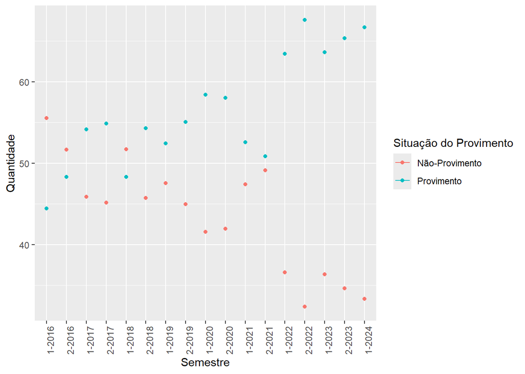

```r
#Particular por semestre
dados_agrupados42 <- subset(novo_df, novo_df$`Principal Parte Ativa` == 'Particular') %>%
  group_by(Ano, Semestre, `Situação do Provimento`) %>%
  summarise(Contagem = n())

total_por_semestre <- dados_agrupados42 %>%
  group_by(Ano, Semestre) %>%
  summarise(Total = sum(Contagem))

dados_agrupados42 <- merge(dados_agrupados42, total_por_semestre, by = c("Ano", "Semestre"))

dados_agrupados42$Percentual <- (dados_agrupados42$Contagem / dados_agrupados42$Total) * 100


ggplot(dados_agrupados42, aes(x = interaction(Semestre, Ano, sep = "-"), y = Percentual, color = `Situação do Provimento`)) +
  geom_line() +
  geom_point() +
  labs(x = "Semestre", y = "Quantidade") +
  theme(axis.text.x = element_text(angle = 90, hjust = 1))
```

## Novas ações distribuídas:

#Agora iniciaremos analisando a segunda base de dados na qual temos os processos #em primeira instância e iremos verificar quantas novas ações foram propostas após a #alteração na LIA’’’

```r
primeira_df <- BasePrimeira %>%
  mutate(`Principal Parte Ativa` = case_when(
    str_detect(`Principal Parte Ativa`, "Ministério") ~ "Ente 1",
    str_detect(`Principal Parte Ativa`, "Prefeitura") |
      str_detect(`Principal Parte Ativa`, "Município") |
      str_detect(`Principal Parte Ativa`, "Estado") |
      str_detect(`Principal Parte Ativa`, "MUNICÍPIO") |
      str_detect(`Principal Parte Ativa`, "PREFEITURA") ~ "Ente 2",
    TRUE ~ "Ente 2"
  ))


primeira_df <- primeira_df %>%
  filter(`Assunto` %in% c('Improbidade Administrativa'))

primeira_df$Entrada <- dmy(primeira_df$Entrada)
primeira_df <- primeira_df %>%
  filter(primeira_df$Entrada >= '2017-01-01')


primeira_df$Ano <- format(primeira_df$Entrada, "%Y")
primeira_df$Mes <- format(primeira_df$Entrada, "%m")
```

#Total por ano, parte indiscriminada - Percentual aparentemente mostra que o MP avocou as #ações para sua competência, dada a mudança de quem poderá entrar com ações agora.

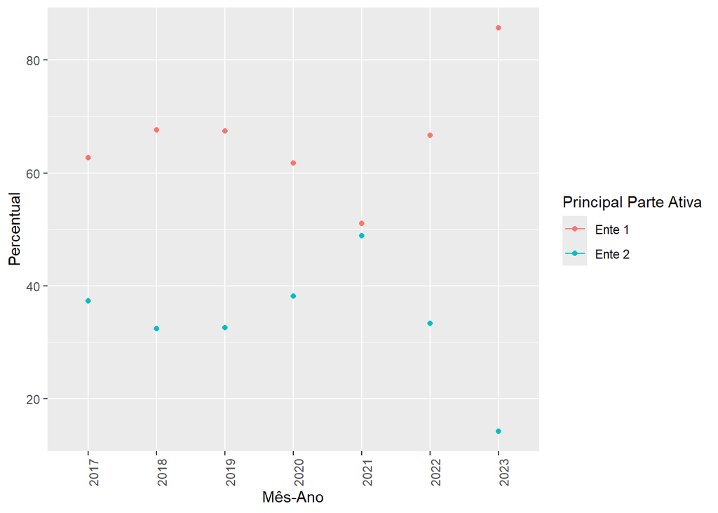

```r
dados_primeira1 <- primeira_df %>%
  group_by(Ano, `Principal Parte Ativa`) %>%
  summarise(Contagem = n())

total_por_ano <- dados_primeira1 %>%
  group_by(Ano) %>%
  summarise(Total = sum(Contagem))

dados_primeira1 <- merge(dados_primeira1, total_por_ano, by = c("Ano"))

dados_primeira1$Percentual <- (dados_primeira1$Contagem / dados_primeira1$Total) * 100


ggplot(dados_primeira1, aes(x = interaction(Ano, sep = "-"), y = Percentual, color = `Principal Parte Ativa`)) +
  geom_line() +
  geom_point() +
  labs(x = "Mês-Ano", y = "Percentual") +
  theme(axis.text.x = element_text(angle = 90, hjust = 1))
```

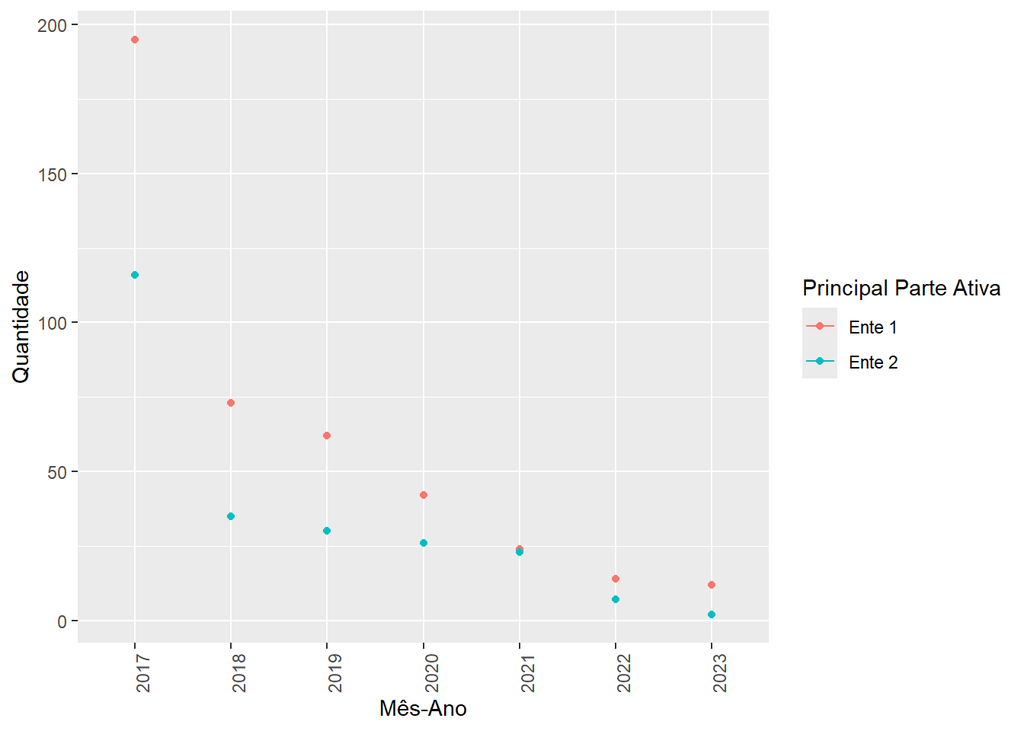

```r
dados_primeira2 <- primeira_df %>%
  group_by(Ano, `Principal Parte Ativa`) %>%
  summarise(Contagem = n())

total_por_ano <- dados_primeira2 %>%
  group_by(Ano) %>%
  summarise(Total = sum(Contagem))

dados_primeira2 <- subset(dados_primeira2, dados_primeira2$Ano >2016)

ggplot(dados_primeira2, aes(x = interaction(Ano, sep = "-"), y = Contagem, color = `Principal Parte Ativa`)) +
  geom_line() +
  geom_point() +
  labs(x = "Mês-Ano", y = "Quantidade") +
  theme(axis.text.x = element_text(angle = 90, hjust = 1))
```